# Pandemia de vacunados

```r
library(readr)
library(dplyr)
library(lubridate)
library(ggplot2)
library(stringr)
library(kableExtra)
library(forcats)
library(rlang)
```

```r
positivos <- read_delim("2022_02_08_positivos_covid.csv", delim = ";") %>%
    mutate_at(
        vars(contains("FECHA")),
        function(x) { as.Date(as.character(x), "%Y%m%d") }
    )
tmp <- colnames(positivos)
tmp[5] <- "METODO"
colnames(positivos) <- tmp
```

```r
positivos
```

| FECHA_CORTE | DEPARTAMENTO | PROVINCIA | DISTRITO | METODO | EDAD | SEXO | FECHA_RESULTADO | UBIGEO | id_persona |
| --- | --- | --- | --- | --- | --- | --- | --- | --- | --- |
| 2022-02-06 | CALLAO | CALLAO | CALLAO | PR | 25 | MASCULINO | 2020-06-19 | 070101 | 24662494 |
| 2022-02-06 | LIMA | LIMA | CHORRILLOS | PR | 37 | FEMENINO | 2020-09-12 | 150108 | 24662689 |
| 2022-02-06 | LIMA | LIMA | SAN MARTIN DE PORRES | PR | 25 | MASCULINO | 2020-12-17 | 150135 | 24662153 |
| 2022-02-06 | AREQUIPA | AREQUIPA | AREQUIPA | PCR | 27 | MASCULINO | 2022-01-20 | 040101 | 24662155 |
| 2022-02-06 | ICA | PISCO | PISCO | PR | 20 | FEMENINO | 2020-08-22 | 110501 | 24662175 |
| 2022-02-06 | ICA | EN INVESTIGACIÓN | EN INVESTIGACIÓN | AG | 22 | FEMENINO | 2022-01-15 | NA | 24662193 |
| 2022-02-06 | HUANUCO | HUANUCO | HUANUCO | PR | 22 | FEMENINO | 2020-07-29 | 100101 | 24662197 |
| 2022-02-06 | ANCASH | SANTA | SANTA | AG | 18 | FEMENINO | 2021-06-30 | 021808 | 24662204 |
| 2022-02-06 | ANCASH | SANTA | NUEVO CHIMBOTE | AG | 17 | MASCULINO | 2021-04-04 | 021809 | 24662207 |
| 2022-02-06 | LIMA | LIMA | LIMA | AG | 25 | FEMENINO | 2022-01-19 | 150101 | 24662229 |

[output cut: 990 more lines]

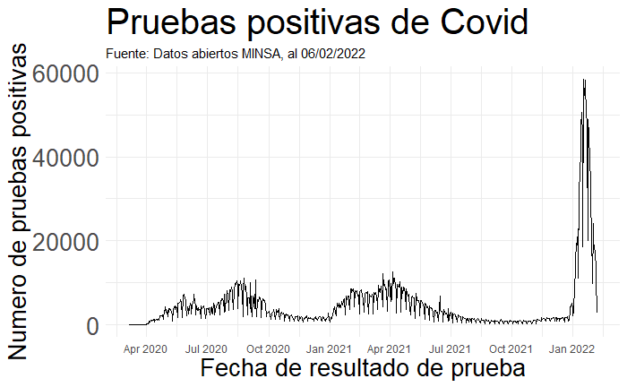

```r
positivos %>%
    count(FECHA_RESULTADO) %>%
    ggplot() +
    geom_line(aes(x=FECHA_RESULTADO, y = n)) +
    labs(
        title= "Pruebas positivas de Covid",
        subtitle ="Fuente: Datos abiertos MINSA, al 06/02/2022",
        x = "Fecha de resultado de prueba",
        y = "Numero de pruebas positivas"
    ) +
  scale_x_date(breaks = scales::breaks_pretty(10))+
  theme_minimal() +
  theme(
      plot.title = element_text(size=30),
      axis.title = element_text(size=20),
      # axis.ticks = element_text(size=14),
      axis.text.y=element_text(size=20)
  )
```

```r
if (!file.exists(paste0(Sys.Date(), "_", "resumen_vacunacion.csv")))
{
    # De https://www.datosabiertos.gob.pe/dataset/vacunacion
    # Ver en el get-data-minsa.bash como lo proceso para obtener vacunas_proyeccion.csv

    vacunacion <- read_csv("2022_02_08_vacunas_proyeccion.csv")
    n_vacs <- count(vacunacion, id_persona)
    write_csv(n_vacs, paste0(Sys.Date(), "_", "resumen_vacunacion.csv")) # reduce rows
} else{
    n_vacs <- read_csv(paste0(Sys.Date(), "_", "resumen_vacunacion.csv"))
}
```

Corte al 15/12/2021 - Filter from 15/12/2021 to 06/02/2022 15/12/21 is when the so called 3rd wave started……and also the beginning of the ‘obligation’ of a vaccinepass/ID/QR ¿Por qué elegir esta fecha de corte?

- Para ver unos dias antes del inicio de la 3era ola
- Por el inicio del “carnet de vacunacion”

```r
positivos %>%
    filter(FECHA_RESULTADO >= as.Date("15/12/2021", "%d/%m/%Y")) %>%
    nrow()
```

```
[1] 1107038
```

#### Cruzando positivos con vacunados

Se puede comprobar el cruce haciendo una busqueda del ID PERSONA en la data original y comparando la edad. Tal vez valdria la pena hacer la proyeccion con edad para comprobar que los datos esten bien cruzados. Haciendo una muestrita a dedo, parece bien

grep 24662352 2022_01_24_TB_VACUNACION_COVID19/TB_VACUNACION_COVID19.csv grep 24662596 2022_01_24_TB_VACUNACION_COVID19/TB_VACUNACION_COVID19.csv grep 24662367 2022_01_24_TB_VACUNACION_COVID19/TB_VACUNACION_COVID19.csv

```r
con_vac <-
    positivos %>%
    filter(FECHA_RESULTADO >= as.Date("15/12/2021", "%d/%m/%Y")) %>%
    left_join(n_vacs)
```

Notar que en los datos de positividad hay ID_PERSONA vacios, por lo que no puedo decir si estan vac, no vac o que ? In the positivos : con_vac are empty id_persona’s so we don’t know if they are vaxxed or not or something else ?

```r
all_vaxxed <- nrow(con_vac)
all_vaxxed # Show the amount of all tested persons since 15/12/2021 :
```

```
[1] 1107038
```

Now let’s correct and remove empty id_persona :

```r
con_vac <- filter(con_vac, !is.na(id_persona))
nrow(con_vac)
```

```
[1] 1083492
```

So there are a # of records of tested people, with no id_persona:

```r
all_vaxxed_no_id <- all_vaxxed - nrow(con_vac)
all_vaxxed_no_id
```

```
[1] 23546
```

estos # positivos que no se puede saber su estado de vacunacion These # positives we have no idea about vaxxed status

Porcentaje general de positividad segun dosis

```r
con_vac %>%
    count(n, sort=F, name = 'nn') %>%
    mutate(
        p = round(nn/nrow(con_vac)*100, 3),
        n = if_else(is.na(n), "0", as.character(n))
    ) %>%
    rename(
        `Número de dosis` = n,
        `Número de positivos` = nn,
        `Porcentaje del total de positivos` = p,
    ) %>%
      kbl(
          caption = "Distribución de pruebas positivas según estado de vacunación, desde 15/12/2021 hasta 06/02/2022"
         ) %>%
    kable_material_dark()
```

Distribución de pruebas positivas según estado de vacunación, desde 15/12/2021 hasta 06/02/2022

| Número de dosis | Número de positivos | Porcentaje del total de positivos |
| --- | --- | --- |
| 1 | 45886 | 4.235 |
| 2 | 607720 | 56.089 |
| 3 | 342581 | 31.618 |
| 4 | 6 | 0.001 |
| 0 | 87299 | 8.057 |

```r
con_vac %>%
    count(id_persona, name='positivos_x_persona') %>%
    count(positivos_x_persona, sort=T) %>%
    mutate(p = round(n/sum(n)*100, 3)) %>%
    rename(
        `Número de veces positivo` = positivos_x_persona,
        `Número de personas` = n,
        `Porcentaje del total` = p,
    ) %>%
    kbl(
        caption = "<b style='color:black !important; text-align:center !important;'>Distribución de pruebas positivas según número de positivos por cada persona, desde 15/12/2021 hasta 06/02/2022</b>",
    ) %>%
    kable_paper(full_width=F)
```

**Distribución de pruebas positivas según número de positivos por cada persona, desde 15/12/2021 hasta 06/02/2022**

| Número de veces positivo | Número de personas | Porcentaje del total |
| --- | --- | --- |
| 1 | 1010537 | 96.550 |
| 2 | 35403 | 3.383 |
| 3 | 680 | 0.065 |
| 4 | 26 | 0.002 |
| 5 | 1 | 0.000 |

Notar que, en este periodo de 15/12 - 06/02 hay:

- 26 personas que dan 4 veces positivo
- 680 que dan 3 veces positivos
- 35403 que dan 2 veces positivo (razonable ?, habria que ver)

Las duplicaciones suenan razonables, pero 3 o 4 suena raro… Facil y se hicieron la prueba varias veces. Igual, el 96.5% de los datos corresponde a personas que salieron positivo 1 sola vez

Verlo por proporciones diarias afianza la idea

```r
gc()
```

```
            used   (Mb) gc trigger   (Mb)  max used   (Mb)
Ncells   1291764   69.0   62719471 3349.6  78399338 4187.0
Vcells 142307785 1085.8  464258114 3542.1 463508453 3536.3
```

Saves some GiB’s, helps prevent crashing R

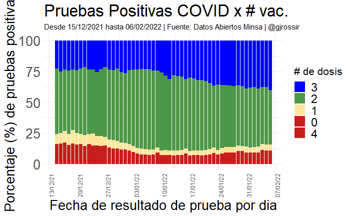

```r
con_vac %>%
    rename(n_dosis=n) %>%
    count(FECHA_RESULTADO, n_dosis, name='x_dia_x_dosis') %>%
    group_by(FECHA_RESULTADO) %>%
    mutate(
        p = x_dia_x_dosis/sum(x_dia_x_dosis)*100,
        n_dosis = forcats::fct_rev(if_else(is.na(n_dosis), "0", as.character(n_dosis)))
    ) %>%
    ggplot() +
    geom_col(aes(x=FECHA_RESULTADO, y = p, fill=n_dosis)) +
    labs(
        title = "Pruebas Positivas COVID x # vac.",
        subtitle = "Desde 15/12/2021 hasta 06/02/2022 | Fuente: Datos Abiertos Minsa | @gjrossir",
        y = "Porcentaje (%) de pruebas positivas",
        x = "Fecha de resultado de prueba por dia",
        fill = "# de dosis"
    ) +
    scale_x_date(date_breaks = "1 week", date_labels =  "%d/%m/%y")  +
    scale_fill_manual(values = rev(c("#000000", "#c71e1d", "#c71e1d","#ffe59c", "#4D9748", "#0000FF"))) +
    theme_minimal() +
    theme(
        plot.title = element_text(size=25),
        axis.title = element_text(size=20),
        # axis.ticks = element_text(size=14),
        axis.text.x=element_text(angle=90),
        axis.text.y=element_text(size=20),
        legend.text = element_text(size=18),
        legend.title = element_text(size=16)
    )
```

### Viendolo por metodos

```r
count(con_vac, METODO,sort=T) %>%
    rename(
        `Tipo de prueba` = METODO,
        `Número de pruebas` = n
    ) %>%
    kbl(
        caption = "<b style='color:black !important; text-align:center !important;'>Distribución de pruebas positivas según tipo de prueba,<br>desde 15/12/2021 hasta 06/02/2022</b>",
    ) %>%
    kable_paper(full_width=F)
```

Distribución de pruebas positivas según tipo de prueba, desde 15/12/2021 hasta 06/02/2022

| Tipo de prueba | Número de pruebas |
| --- | --- |
| AG | 766727 |
| PCR | 315940 |
| PR | 825 |

```r
    # kable_material_dark(full_width = F, )
```

##### Disclaimer en los datos abiertos

Es el registro diario de casos positivos de covid-19 confirmados con cualquier tipo de prueba y que presentan síntomas. Cada registro es igual a una persona, la cual puede caracterizarse por sexo, edad y ubicación geográfica hasta nivel de distrito.

Directiva Sanitaria para la vigilancia epidemiológica de la enfermedad de Coronavirus en el Perú, aquí se establece los lineamientos y procedimientos de identificación de casos positivos, para más detalle ver el link:

https://www.gob.pe/institucion/minsa/normas-legales/1322786-905-2020-minsa

Nota: Desde el 02/06/2020 los casos por PR no incluye las IPRESS privadas que realizan tamizaje a trabajadores de empresas en el marco de la reactivación económica, debido a que el objetivo de este tamizaje NO permite identificar casos nuevos en personas sospechosas